# EpiCompare Report

Jun-10-2022

```r
knitr::opts_chunk$set(echo = FALSE)
### Create Output Directory ###
# if save_output = TRUE
if(params$save_output){
  outfile_dir <- paste0(params$output_dir,"/EpiCompare_file")
  if(!dir.exists(outfile_dir)){
    dir.create(outfile_dir, showWarnings = FALSE, recursive = TRUE)
  }
}

#### ------ Prepare genome builds ------ ####
# e.g. genome_build <- list(reference="hg19",peakfiles="hg38",blacklist="hg19")
# or... genome_build <- "hg19"
builds <- prepare_genome_builds(genome_build = params$genome_build)
## Standardise all data to hg19 build
output_build <- prepare_output_build(params$genome_build_output)

#### ------ Prepare peaklist(s) ------ ####
# and check that the list is named, if not default filenames are used
peaklist <- prepare_peaklist(peaklist = params$peakfile)
peaklist <- liftover_grlist(grlist = peaklist,
                            input_build = builds$peaklist,
                            output_build = output_build)

#### ------ Prepare reference(s) ------ ####
reference <- prepare_reference(reference = params$reference)
reference <- liftover_grlist(grlist = reference,
                            input_build = builds$reference,
                            output_build = output_build)

#### ------ Prepare blacklist ------ ####
blacklist <- liftover_grlist(grlist = params$blacklist,
                             input_build = builds$blacklist,
                             output_build = output_build)

### Standardise peaklist(s) ###
peaklist_tidy <- tidy_peakfile(peaklist = peaklist,
                               blacklist = blacklist)

### Standardise reference(s) ###
# and include in peaklist
reference_tidy <- reference
if (!is.null(reference)){
  reference_tidy <- tidy_peakfile(peaklist = reference,
                                  blacklist = blacklist)
  peaklist_tidy <- c(peaklist_tidy, reference_tidy)
}

### Obtain Genome Annotation ###
txdb <- check_genome_build(genome_build = output_build)

### Dynamic Figure Height ###
fig_height <- fig_length(default_size = 7,
                         number_of_items = length(peaklist_tidy),
                         max_items = 10)
```

EpiCompare compares epigenetic datasets for quality control and benchmarking purposes. The report consists of three sections:

##### Input Datasets

- Reference peakfile: ENCODE
- Total of 3 peak files:

```
## [1] "File1: CnR"
## [1] "File2: CnT"
## [1] "File3: ENCODE"
```

##### Code

The function call used to create the report.

```r
EpiCompare(peakfiles = list(CnR, CnT, ENCODE),
           genome_build = hg19, hg38, hg19,
           genome_build_output = hg19,
           blacklist = blacklist,
           picard_files = list(CnR, CnT),
           reference = ENCODE,
           upset_plot = FALSE,
           stat_plot = FALSE,
           chromHMM_plot = FALSE,
           chromHMM_annotation = "K562",
           chipseeker_plot = FALSE,
           enrichment_plot = FALSE,
           tss_plot = FALSE,
           precision_recall_plot = FALSE,
           corr_plot=FALSE,
           interact = FALSE,
           save_output = FALSE,
           output_dir = "/tmp/RtmpbSUn7L")
```

## 1. General Metrics

### Peak Information

Column Description:

- PeakN before tidy: Total number of peaks including those blacklisted and those in non-standard chromosomes.
- Blacklisted peaks removed (%): Percentage of blacklisted peaks in samples. E.g. [ENCODE hg19 blacklist](https://www.encodeproject.org/files/ENCFF000KJP/) includes regions in the hg19 genome that have anomalous and/or unstructured signals independent of the cell-line or experiment.
- Non-standard peaks removed (%): Percentage of peaks in non-standard and/or mitochondrial chromosomes. Identified using `BRGenomics::tidyChromosomes()`.
- PeakN after tidy: Total number of peaks after removing those in blacklisted regions and non-standard chromosomes.

**NB**: EpiCompare uses *filtered* peakfiles (i.e. datasets after removing peaks in blacklisted regions and non-standard chromosomes)

```
## --- Running peak_info() ---
```

```
## Done.
```

|  | PeakN Before Tidy | Blacklisted Peaks Removed (%) | Non-standard Peaks Removed (%) | PeakN After Tidy |
| --- | --- | --- | --- | --- |
| CnR | 2707 | 0.222 | 0 | 2701 |
| CnT | 1670 | 0.299 | 0 | 1665 |

### Fragment Information

Metrics on fragments is shown only if Picard summary is provided. See [manual](https://neurogenomics.github.io/EpiCompare/) for help.

Column Description:

- Mapped_Fragments: Number of mapped read pairs in the file.
- Duplication_Rate: Percentage of mapped sequence that is marked as duplicate.
- Unique_Fragments: Number of mapped sequence that is not marked as duplicate.

```
## --- Running fragment_info() ---
```

```
## Done.
```

|  | Mapped_Fragments | Duplication_Rate | Unique_Fragments |
| --- | --- | --- | --- |
| CnR | 5523031 | 7.30 | 5120026 |
| CnT | 2293087 | 20.18 | 1830390 |

### Peak widths

Distribution of peak widths in samples

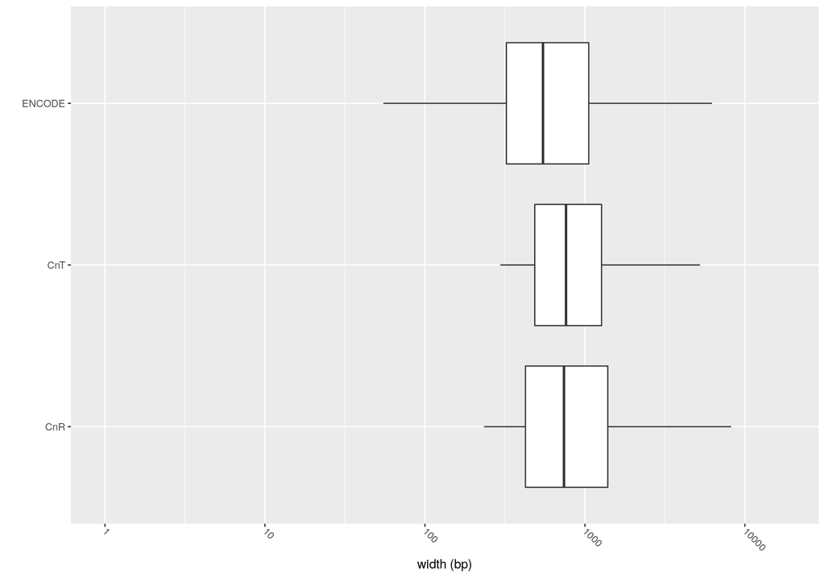